# Årsrapport fangster MV-LF 2025

2026-04-30

Denne rapport giver et overblik over fangsterne for 2025 og kan bruges til at besvare spørgsmål som: På hvilke strækninger bliver der fanget fisk? Hvor mange blev genudsat? Den kan derfor bruges af bestyrelsen til at lave mere valide beslutninger om fx hvilke fiskevande der skal opsiges mm

# 1 Karup Å systemet

## 1.1 MV-LF

Vi betragter fangstdata fra MV-LF i Karup Å systemet. Et overblik er givet i Tabel 1.1. Bemærk at vægten for alle genudsatte fisk er estimeret baseret på [vægt data for Karup Å](https://relund.github.io/riverdata/karup/karup-salmometer.html).

Table 1.1: Overblik over fangstdata for 2025 (MV-LF)

| Antal fanget | 344 |
| --- | --- |
| Genudsat | 46 % |
| Gennesnitsvægt | 2.46 |
| Gennesnitsvægt hjemtaget | 2.86 |
| Gennesnitsvægt genudsat | 1.99 |
| Største fisk hjemtaget | 8.2 kg, 84 cm af Albert Deischl på Flue |
| Største fisk genudsat | 5.87 kg, 80 cm af Allan Nørskov Johansen på Flue |
| Strækninger | 33 |
| Bedste strækning | Barslundstykket |

### 1.1.1 Fordeling af fangster over strækninger

Bemærk at der helt sikkert vil være nogle fangster som er indrapporteret på de forkerte strækninger. Da det er første år i foreningen har der i nogle tilfælde været forvirring om hvilken strækning en fisk er fanget på. Dette vil blive bedre med tiden.

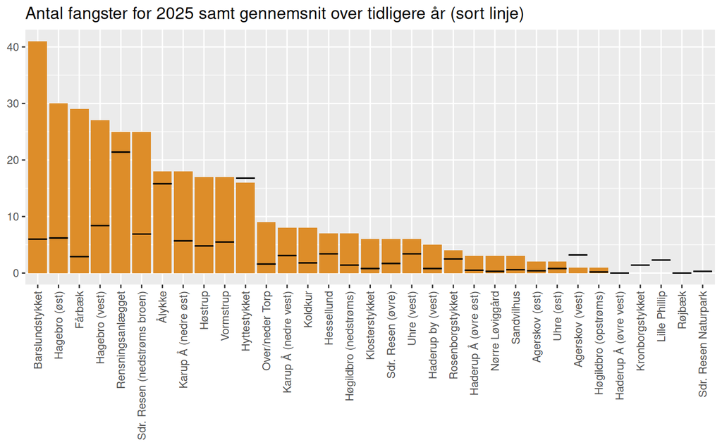

### 1.1.2 Fordeling af antal fisk hjemtaget

Bemærk det er antaget at folk har angivet samme navn. Der er en risiko for at folk der hjemtager mange fisk vælger at skrive deres navn forskelligt, så det er svære at identificere hjemtagelse af mange fisk.

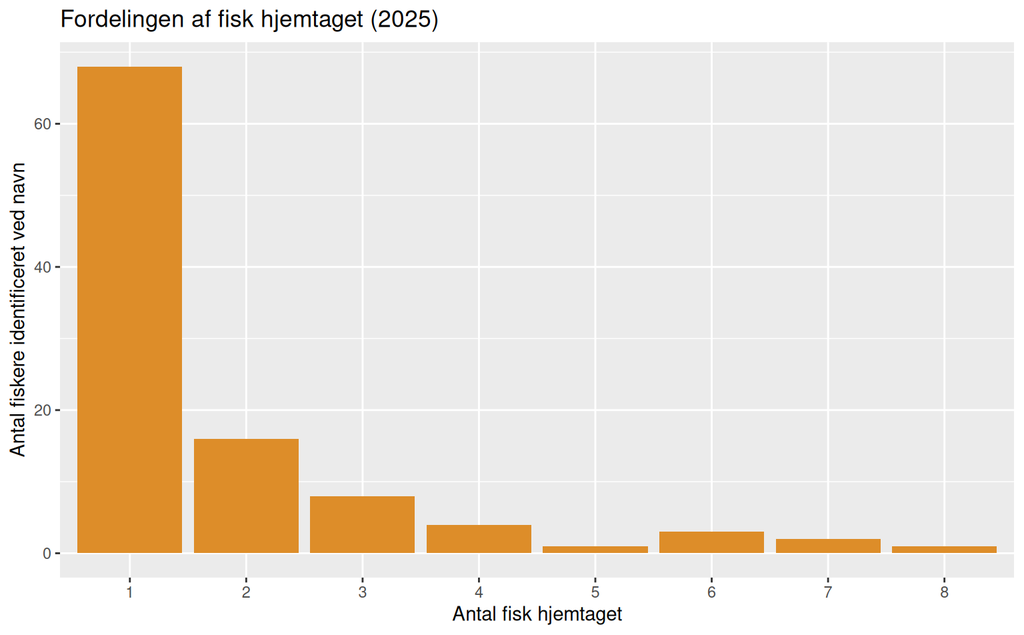

### 1.1.3 Fordeling af antal kg hjemtaget

Her kigger vi på det totale antal kg fiske hjemtaget, da 5 små havørreder jo vejer mindre end 5 store.

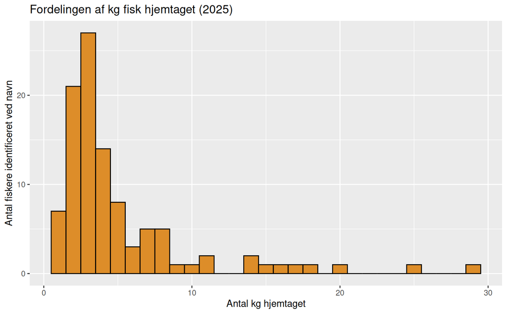

## 1.2 Hele Karup Å systemet

Vi kigger her på fangstdata for hele Karup Å systemet (alle foreninger).

Table 1.2: Overblik over fangstdata for 2025 (hele å systemet)

| Antal fanget | 1162 |
| --- | --- |
| Genudsat | 40 % |
| Gennesnitsvægt | 2.56 |
| Gennesnitsvægt hjemtaget | 3 |
| Gennesnitsvægt genudsat | 1.91 |
| Største fisk hjemtaget | 8.328 kg, 84 cm af Esben Hougaard Sørensen på Flue |
| Største fisk genudsat | 6.9 kg, 83 cm af Dan Sloth på Flue |
| Strækninger | 4 |
| Bedste strækning | Nedre |

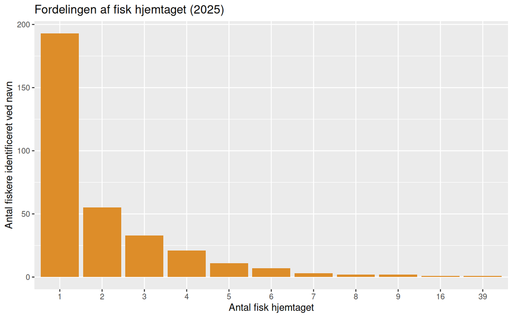

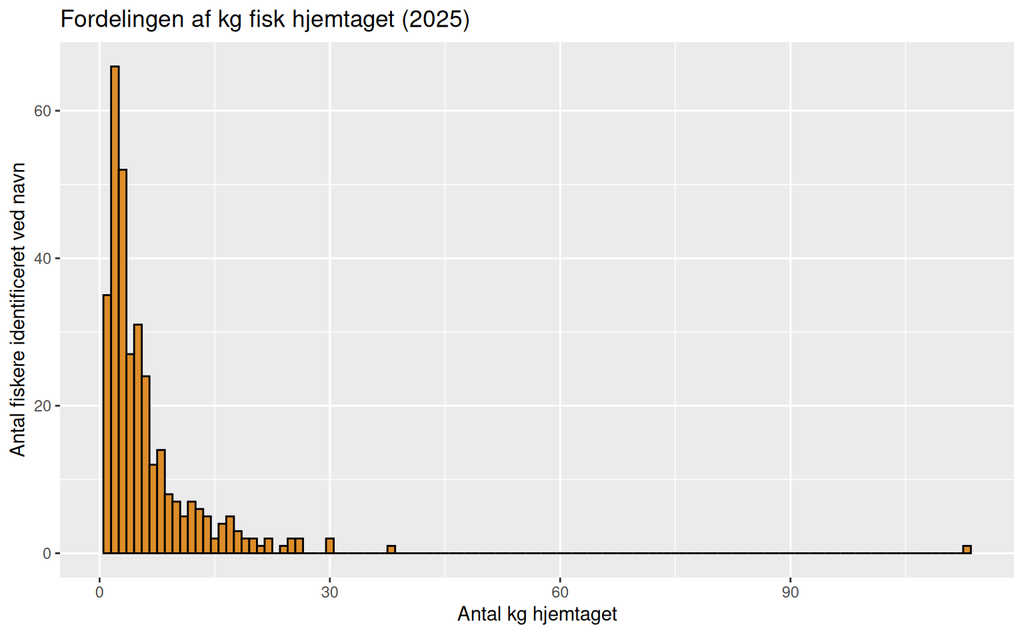

### 1.2.1 Effekter af kvoter

Der har været en diskussion omkring mådehold ved åen. For at holde denne diskussion på rette spor er lavet følgende analyse. Bemærk denne analyse er ikke ment som et argument for eller imod kvoter, men kan bruges til at holde diskussionen i forhold til faktiske data.

Hvis vi antager at der laves et kvote system hvor max $y$ antal fisk må hjemtages over $x$ cm, kan der givet dette års fangster udregnes hvad effekten af at indføre et kvotesystem ville have været.

Antagelser

- Kigger på fangster for nuværende år.
- Vi filtrer fangsterne så kun kigger på hjemtaget fisk.
- Vi kigger herefter på fisk over grænsen i cm og fjerner de første fangster givet et maks antal, der må fanges per fisker.
- Vi har herefter fangsterne der (hvis kvoten gælder) skulle have være genudsat.
- Vi filtrer for hunner eller ukendt køn (antages hun).
- For hver fisk estimeres vægt og antal æg fisken ville have lagt.
- Det antages at 0.25% - 1% af disse æg bliver til tilbagevendende fisk (er ikke sikker på disse tal), dvs. gennemsnitligt 0.5%.

Table 1.3: Estimat af antal æg givet havørredens længde (kilde ukendt)

| Længde | Antal æg |
| --- | --- |
| 30 | 700 |
| 40 | 1700 |
| 50 | 3200 |
| 60 | 5500 |
| 70 | 8700 |
| 80 | 12900 |
| 90 | 18300 |

Effekten af kvoterne kan ses i nedenstående tabel, fx hvis man kun måtte hjemtage 3 fisk over 70 cm vil effekten være at 6 fisk ville have været genudsat, disse vejede tilsammen 29.36 kg. Fiskene ville lægge 62073 æg der ville give ca 310 [155, 621] fisk som vente tilbage (intervallet er givet i firkantet parenteser). Bemærk at hvis er optræder nuller alle steder under effekt tallene betyder det at kvoterne ikke har nogen effekt.

Table 1.4: Effekt af kvoter

| Kvote >cm | Kvote Max antal | Effekt Fisk | Effekt Kg | Effekt Æg | Effekt Retur |
| --- | --- | --- | --- | --- | --- |
| 70 | 1 | 20 | 100.39 | 206074 | 1030 [515, 2061] |
| 70 | 2 | 8 | 39.27 | 82567 | 413 [206, 826] |
| 70 | 3 | 6 | 29.36 | 62073 | 310 [155, 621] |
| 70 | 4 | 4 | 20.36 | 43570 | 218 [109, 436] |
| 70 | 5 | 3 | 15.40 | 33329 | 167 [83, 333] |
| 75 | 1 | 0 | 0.00 | 0 | 0 [0, 0] |
| 75 | 2 | 0 | 0.00 | 0 | 0 [0, 0] |
| 75 | 3 | 0 | 0.00 | 0 | 0 [0, 0] |
| 75 | 4 | 0 | 0.00 | 0 | 0 [0, 0] |
| 75 | 5 | 0 | 0.00 | 0 | 0 [0, 0] |

# 2 Skjern Å systemet

## 2.1 MV-LF

Vi betragter fangstdata fra MV-LF i Skjern Å systemet. Bemærk at vægten for alle genudsatte fisk er estimeret baseret på [vægt data for Skjern Å](https://relund.github.io/riverdata/skjern/skjern-salmometer.html).

### 2.1.1 Laks

Et overblik er givet i Tabel 2.1.

Table 2.1: Overblik over fangstdata for 2025 (MV-LF)

[output not shown]

#### 2.1.1.1 Fordeling af fangster over strækninger

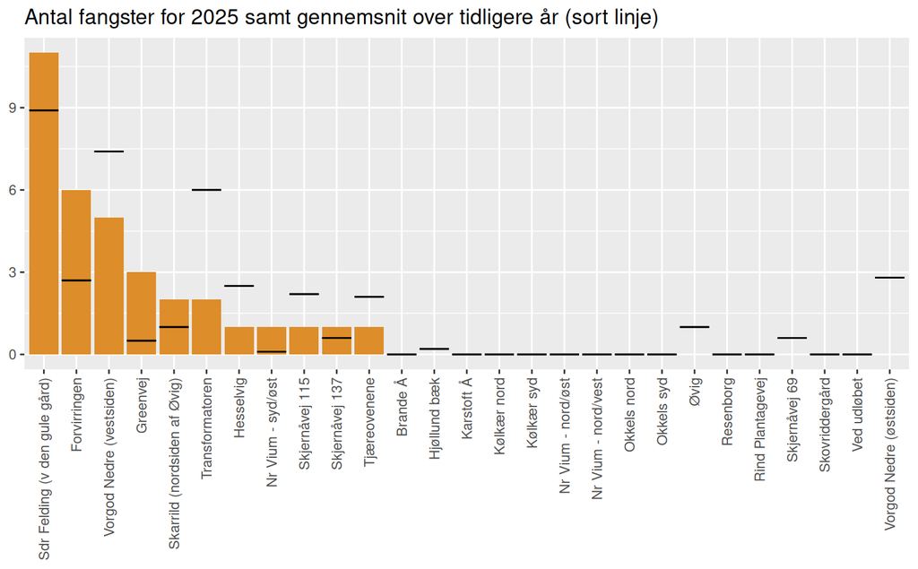

### 2.1.2 Havørred

Table 2.2: Overblik over fangstdata for 2025

| Antal fanget | 28 |
| --- | --- |
| Genudsat | 100 % |
| Gennesnitsvægt | 1.63 |
| Gennesnitsvægt hjemtaget | NA |
| Gennesnitsvægt genudsat | 1.63 |
| Største fisk hjemtaget | NA |
| Største fisk genudsat | 3.4 kg, 65 cm af Erik Jensen på Spin |
| Strækninger | 27 |
| Bedste strækning | Sdr Felding (v den gule gård) |

#### 2.1.2.1 Fordeling af fangster over strækninger

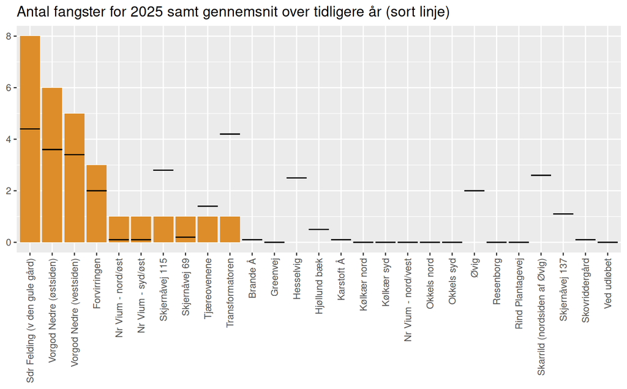

### 2.1.3 Bækørred

Table 2.3: Overblik over fangstdata for 2025

| Antal fanget | 1 |
| --- | --- |
| Genudsat | 100 % |
| Gennesnitsvægt | 0.78 |
| Gennesnitsvægt hjemtaget | NA |
| Gennesnitsvægt genudsat | 0.78 |
| Største fisk hjemtaget | NA |
| Største fisk genudsat | 0.78 kg, 40 cm af Thomas Stjernegaard Jeppesen på Flue |
| Strækninger | 27 |
| Bedste strækning | Kølkær syd |

#### 2.1.3.1 Fordeling af fangster over strækninger

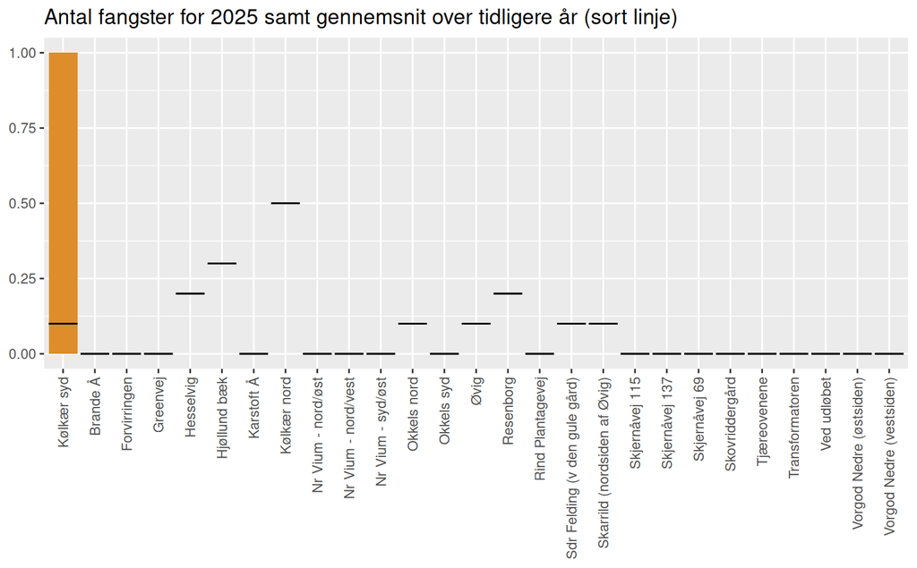

### 2.1.4 Stalling

Table 2.4: Overblik over fangstdata for 2025

| Antal fanget | 1 |
| --- | --- |
| Genudsat | 100 % |
| Gennesnitsvægt | 1.04 |
| Gennesnitsvægt hjemtaget | NA |
| Gennesnitsvægt genudsat | 1.04 |
| Største fisk hjemtaget | NA |
| Største fisk genudsat | 1.04 kg, 45 cm af Dylan Svendsen på Flue |
| Strækninger | 27 |
| Bedste strækning | Sdr Felding (v den gule gård) |

#### 2.1.4.1 Fordeling af fangster over strækninger

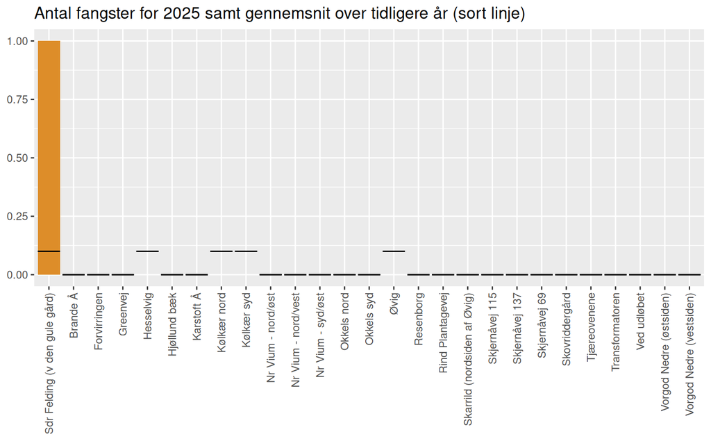

## 2.2 Hele Skjern Å systemet

Vi kigger her på fangstdata for hele Skjern Å systemet (alle foreninger).

Table 2.5: Havørred: Overblik over fangstdata for 2025 (hele å systemet)

| Antal fanget | 351 |
| --- | --- |
| Genudsat | 99 % |
| Gennesnitsvægt | 1.84 |
| Gennesnitsvægt hjemtaget | 1.08 |
| Gennesnitsvægt genudsat | 1.84 |
| Største fisk hjemtaget | 1.41 kg, 50 cm af Emil Gyldenkærne på Spin |
| Største fisk genudsat | 5.36 kg, 75 cm af Jean-Marie Depireux på Spin |
| Strækninger | 8 |
| Bedste strækning | Nedre |

Table 2.6: Laks: Overblik over fangstdata for 2025 (hele å systemet)

| Antal fanget | 842 |
| --- | --- |
| Genudsat | 100 % |
| Gennesnitsvægt | 4.64 |
| Gennesnitsvægt hjemtaget | NA |
| Gennesnitsvægt genudsat | 4.64 |
| Største fisk hjemtaget | NA |
| Største fisk genudsat | 20.88 kg, 131 cm af Ariejan Kool på Flue |
| Strækninger | 6 |
| Bedste strækning | Nedre |

[figure not shown]